# Group3-LiveAssignment5

```python
#  Ebnable HTML/CSS
from IPython.core.display import HTML
HTML("<link href='https://fonts.googleapis.com/css?family=Passion+One' rel='stylesheet' type='text/css'><style>div.attn { font-family: 'Helvetica Neue'; font-size: 30px; line-height: 40px; color: #FFFFFF; text-align: center; margin: 30px 0; border-width: 10px 0; border-style: solid; border-color: #5AAAAA; padding: 30px 0; background-color: #DDDDFF; }hr { border: 0; background-color: #ffffff; border-top: 1px solid black; }hr.major { border-top: 10px solid #5AAA5A; }hr.minor { border: none; background-color: #ffffff; border-top: 5px dotted #CC3333; }div.bubble { width: 65%; padding: 20px; background: #DDDDDD; border-radius: 15px; margin: 0 auto; font-style: italic; color: #f00; }em { color: #AAA; }div.c1{visibility:hidden;margin:0;height:0;}div.note{color:red;}</style>")
```

Enter Team Member Names here (double click to edit):

- Name 1: Yucheol Shin
- Name 2: Jorge Olmos
- Name 3: Bosang Yun
- Name 4: Siu Wai Yeung

# In Class Assignment Five

In the following assignment you will be asked to fill in python code and derivations for a number of different problems. Please read all instructions carefully and turn in the rendered notebook (or HTML of the rendered notebook) before the end of class. Be sure to save the notebook before uploading.

## Contents

- Testing R Magics
- Understanding the Data Representation
- Finding Frequent Items
- Generating Candidates
- Using ARules and ARulesViz

Back to Top

## Running in the 'R' Ecosystem with magics

If you did not get Rpy2, R, or the dependencies arules and arulesViz installed on your system, then you will need to skip this part and go on to the first question. You will need to run the appropriate block of code in this notebook depending on if you have Rpy2 running or not. Each block is marked appropriately, so read the block before running it.

```python
# getting things started
import time
import matplotlib.pyplot as plt
import numpy as np
import pandas as pd
%matplotlib inline
```

```python
#==========================
#IF USING R, RUN THIS CODE
#==========================
# You will need to have R installed, as well as Rpy2 and the arules library
from rpy2.robjects.packages import importr
from rpy2 import robjects as robj

# this way we can write r code by simply writing %R
%load_ext rmagic
%load_ext rpy2.ipython
# this enables the %R extension to iPython (does not work outside of the iPython shell)

# these packages will need to be installed
# open R and run
#     install.package(arules)
#     install.package(arulesViz)

arules = importr('arules') # same as importing in R with the "library" command
arules_viz = importr('arulesViz') # visualize the different rules
```

[output not shown]

If you receive a warning on the above block, try to run it again and verify that everything is loaded properly.

[output not shown]

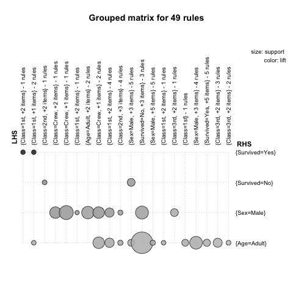

```
Arules run now from R, test complete
```

```python
#==========================
#IF USING R, RUN THIS CODE
#==========================

%R load("titanic2.raw.rdata")
%R rules <- apriori(titanic.raw,parameter = list(minlen=2, supp=0.05, conf=0.8))
%R rules.sorted <- sort(rules, by="lift")
%R plot(rules.sorted, method="grouped")

print('Arules run now from R, test complete')
```

Back to Top

## Understanding the dataset

We have used the titanic dataset before in class, however this dataset has been pruned to only include the social class, sex, age (as a nominal), and if the individual survived. The data can be stored in many ways, but is stored here as a table of values.

**Question**: Is this dataset a typical example of *transaction* data (*i.e.*, like the grocery store transaction data)? Why or Why not? What makes it similar or different? **Hint**: think about the possible itemset lattice and how it might be different/similar. What makes an item in this dataset?

Enter your answer here:

- This is not an transaction data but it is similar as it can have multiple itemsets of interest.

Back to Top

## Frequent Itemsets and Apriori

Run the following line of code to grab the R loaded data.frame and save it into a pandas dataframe.

Please run the appropriate block of code for whether you have Ry2 installed or not!

```python
#==========================
#IF USING R, RUN THIS CODE
#==========================
# Use rmagics to save the dataframe into pandas
#(R output)(python var) ( this is all R code)
%R -o df_from_R df_from_R <- titanic.raw

# now we have the exact same dataset as the one from R
# but it is now a pandas dataframe
print(df_from_R.info())
```

```
UsageError: Line magic function `%R` not found.
```

```python
#===============================
# IF NOT USING R RUN THIS CODE
#===============================
# getting things started
import time
import matplotlib.pyplot as plt
import numpy as np
import pandas as pd
%matplotlib inline

df_from_R = pd.read_csv('Rframe_as_pandas.csv')
df_from_R.info()
```

```
<class 'pandas.core.frame.DataFrame'>
RangeIndex: 2201 entries, 0 to 2200
Data columns (total 5 columns):
 #   Column      Non-Null Count  Dtype
---  ------      --------------  -----
 0   Unnamed: 0  2201 non-null   int64
 1   Class       2201 non-null   object
 2   Sex         2201 non-null   object
 3   Age         2201 non-null   object
 4   Survived    2201 non-null   object
dtypes: int64(1), object(4)
memory usage: 86.1+ KB
```

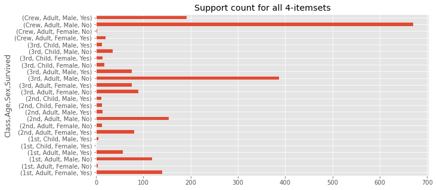

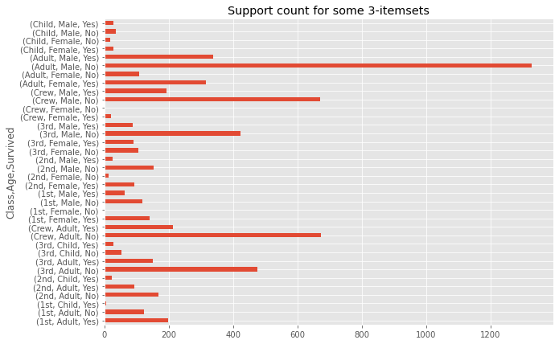

```python
#==========================================
# RUN THIS CODE NO MATTER IF USING R OR NOT
#==========================================
plt.style.use('ggplot')

# Now lets plot the number of times each itemset occurs graphically
# find counts of the four itemsets
f = plt.figure(figsize=(10,5))
df_grouped = df_from_R.groupby(by=['Class','Age','Sex'])
ax = df_grouped.Survived.value_counts().plot(kind='barh')
plt.title('Support count for all 4-itemsets')

# find all the three itemsets and concat them
f = plt.figure(figsize=(10,7))
df_grouped = df_from_R.groupby(by=['Class','Age'])
countsA = df_grouped.Survived.value_counts()
df_grouped = df_from_R.groupby(by=['Class','Sex'])
countsB = df_grouped.Survived.value_counts()
df_grouped = df_from_R.groupby(by=['Age','Sex'])
countsC = df_grouped.Survived.value_counts()

pd.concat((countsA,countsB,countsC)).plot(kind='barh')
plt.title('Support count for some 3-itemsets')
```

Use the graphs above to estimate the values for the following quantities. You do not need to calculate counts from the dataset, just try to get close by viewing from the graph. Recall that for a given rule, $X\rightarrow Y$, the confidence is given by $$c=\frac{\sigma( X \cup Y)}{\sigma( X )} $$

**Questions**: Given the graphs above, what is the support count, $\sigma$, and support, $s$, for the itemset {1st, Adult, Yes}? What about the itemset {1st, Adult, Yes, Female}?

**Question**: What is the confidence, $c$, for the rule {1st, Adult, Yes} $\rightarrow$ {Female}?

Enter your answer here:

1. support of itemset {1st, Adult, Yes} is 197 support counts = 197 / 2201 = 0.0895
2. support of itemset {1st, Adult, Yes, Female} is 140 support counts = 140 / 2201 = 0.0636
3. confidence is 0.71

```python
# Insert any calculations needed to answer the above question here
cnts = df_from_R.groupby(by=['Class','Age', 'Sex','Survived']).count()
print(cnts.iloc[1])
num_XuY = cnts.iloc[1].values

cnts = df_from_R.groupby(by=['Class','Age','Survived']).count()
print(cnts.iloc[1])
num_X = cnts.iloc[1].values

print(float(num_XuY)/num_X)
```

```
Unnamed: 0    140
Name: (1st, Adult, Female, Yes), dtype: int64
Unnamed: 0    197
Sex           197
Name: (1st, Adult, Yes), dtype: int64
[0.7106599 0.7106599]
```

**Question**: What is the support count (an integer) for a *minsup* threshold of 0.25? Using the support count graphs above, which itemsets would be considered frequent with a *minsup* of 0.25? Are any of the 4-itemsets also maximal for this value of *minsup*? Why or Why not?

Enter your answer here:

1. support count of minsup is 550
2. [Adult, Male, No], [Crew, Male, No], [Crew Adult, No]
3. Itemset with [Crew, Adult, Male, No]

```python
# Insert any calculations needed to answer the above question here
sup = 0.25 * 2201
print(int(sup))

cnts = df_from_R.groupby(by=['Class','Age','Sex','Survived']).count()

df_grouped = df_from_R.groupby(by=['Class','Age'])
countsA = df_grouped.Survived.value_counts()
df_grouped = df_from_R.groupby(by=['Class','Sex'])
countsB = df_grouped.Survived.value_counts()
df_grouped = df_from_R.groupby(by=['Age','Sex'])
countsC = df_grouped.Survived.value_counts()

tmp = pd.concat((countsA, countsB, countsC))
print(tmp[tmp>sup])
```

```
550
Class  Age    Survived
Crew   Adult  No           673
       Male   No           670
Adult  Male   No          1329
Name: Survived, dtype: int64
```

# Start of Live Session Assignment

Back to Top

### Generating candidates

Assume that the 3-itemset bar graph above contains ALL the possible frequent 3-itemsets in the titanic dataset and their support count.

**Exercise**: If the minimum support count equals 200, then use the bar graph to select the 3-itemsets that are frequent. Use these itemsets and the apriori principle to generate candidate 4-itemsets that might be frequent. Please show your thought process.

Enter your answer here:

For 3 itemsets - There are 8 itemsets

For 4 itemsets - There are 2 itemsets

Since there are no 5 itemsets, this is the maximal. Thus no superset can have higher support count. These two 4 itemsets are the maximal set.

Back to Top

## Using the Arules Package to Interpret Data

Run the following R code to run the Apriori algorithm on the titanic dataset.

**Exercise**: Change the parameters of the apriori algorithm in order to check your results from the previous question. That is, change the minlen, supp, and conf parameters so that it only displays 4-itemsets with minimum "support count" of 200. Do the itemsets from the resulting rules match with what you found in the previous questions? Should they? Why or why not?

```python
#==========================
# IF USING R RUN THIS CODE
#==========================
%R load("titanic2.raw.rdata")
%R rules <- apriori(titanic.raw,parameter = list(minlen=1, supp=0.01, conf=0.01))
%R rules.sorted <- sort(rules, by="support")
%R inspect(rules.sorted)
```

[output not shown]

```
    lhs               rhs               support confidence      lift
1   {}             => {Age=Adult}    0.95047706 0.95047706 1.0000000
2   {}             => {Sex=Male}     0.78646070 0.78646070 1.0000000
3   {Sex=Male}     => {Age=Adult}    0.75738301 0.96302715 1.0132040
4   {Age=Adult}    => {Sex=Male}     0.75738301 0.79684512 1.0132040
5   {}             => {Survived=No}  0.67696502 0.67696502 1.0000000
6   {Survived=No}  => {Age=Adult}    0.65333939 0.96510067 1.0153856
7   {Age=Adult}    => {Survived=No}  0.65333939 0.68738050 1.0153856
8   {Survived=No}  => {Sex=Male}     0.61971831 0.91543624 1.1639949
9   {Sex=Male}     => {Survived=No}  0.61971831 0.78798382 1.1639949
10  {Sex=Male,
     Survived=No}  => {Age=Adult}    0.60381645 0.97434018 1.0251065
11  {Age=Adult,
     Survived=No}  => {Sex=Male}     0.60381645 0.92420028 1.1751385
12  {Sex=Male,
     Age=Adult}    => {Survived=No}  0.60381645 0.79724055 1.1776688
13  {}             => {Class=Crew}   0.40208996 0.40208996 1.0000000
14  {Class=Crew}   => {Age=Adult}    0.40208996 1.00000000 1.0521033
15  {Age=Adult}    => {Class=Crew}   0.40208996 0.42304015 1.0521033
16  {Class=Crew}   => {Sex=Male}     0.39164016 0.97401130 1.2384742
17  {Sex=Male}     => {Class=Crew}   0.39164016 0.49797805 1.2384742
18  {Class=Crew,
     Sex=Male}     => {Age=Adult}    0.39164016 1.00000000 1.0521033
19  {Class=Crew,
     Age=Adult}    => {Sex=Male}     0.39164016 0.97401130 1.2384742
20  {Sex=Male,
     Age=Adult}    => {Class=Crew}   0.39164016 0.51709658 1.2860221
21  {}             => {Survived=Yes} 0.32303498 0.32303498 1.0000000
22  {}             => {Class=3rd}    0.32076329 0.32076329 1.0000000
23  {Class=Crew}   => {Survived=No}  0.30577010 0.76045198 1.1233254
24  {Survived=No}  => {Class=Crew}   0.30577010 0.45167785 1.1233254
25  {Class=Crew,
     Survived=No}  => {Age=Adult}    0.30577010 1.00000000 1.0521033
26  {Class=Crew,
     Age=Adult}    => {Survived=No}  0.30577010 0.76045198 1.1233254
27  {Age=Adult,
     Survived=No}  => {Class=Crew}   0.30577010 0.46801113 1.1639463
28  {Class=Crew,
     Survived=No}  => {Sex=Male}     0.30440709 0.99554235 1.2658514
29  {Class=Crew,
```

[output cut: 408 more lines]

```
238 {Class=2nd}    => {Age=Child}    0.01090413 0.08421053 1.7004346
239 {Class=2nd,
     Age=Child}    => {Survived=Yes} 0.01090413 1.00000000 3.0956399
240 {Age=Child,
     Survived=Yes} => {Class=2nd}    0.01090413 0.42105263 3.2517082
241 {Class=2nd,
     Survived=Yes} => {Age=Child}    0.01090413 0.20338983 4.1069818
242 {Sex=Female}   => {Class=Crew}   0.01044980 0.04893617 0.1217045
243 {Class=Crew}   => {Sex=Female}   0.01044980 0.02598870 0.1217045
244 {Class=Crew,
     Sex=Female}   => {Age=Adult}    0.01044980 1.00000000 1.0521033
245 {Sex=Female,
     Age=Adult}    => {Class=Crew}   0.01044980 0.05411765 0.1345909
246 {Class=Crew,
     Age=Adult}    => {Sex=Female}   0.01044980 0.02598870 0.1217045
```

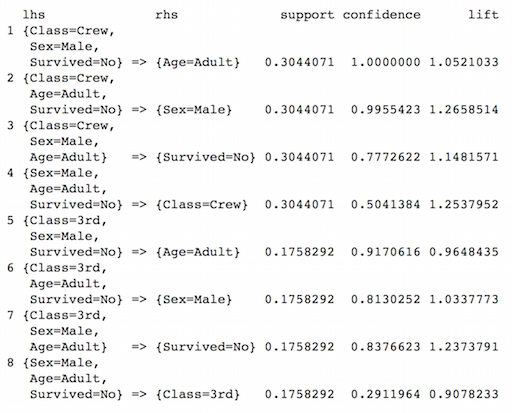

```python
#========================================================================================================
# IF NOT USING R RUN THIS CODE (It is an example snapshot of using arules) AND INTERPRET THE OUTPUTS
#========================================================================================================
from IPython.display import Image
Image('R_arules_output.png')

#========================================================================================================
# Also, change the parameters to the following line of code to what you think they should be to answer the question:
#========================================================================================================

# rules <- apriori(titanic.raw,parameter = list(minlen=1, supp=0.01, conf=0.01))
```

Enter your answer here:

8 of frequent 3 itemsets came out same as previous answer.

They do not need to be match because we assumed everything not in the 3-itemset graph was infrequent.

## Using the Arules Viz Package

Now run the following code to visualize the rules from the previous step. There are various parameters built into the visualization such as support, confidence, and a parameter known as "lift." Lift is a measure that ranks different rules using the equation $$ Lift = \frac{P(Y|X)}{P(Y)} = \frac{c(X\rightarrow Y)}{s(Y)} $$ In practice, there are many different measures that we use to rank the rules from a dataset, but, at the end of the day, a human evaluates which rules are most subjectively interesting. The arulesViz library allows many different types of interpretations for looking at lift and confidence together. The documentation is here: http://cran.r-project.org/web/packages/arulesViz/arulesViz.pdf

The styles of plot are "scatterplot", "two-key plot", "matrix", "matrix3D", "graph", "paracoord" or "grouped." Each provides a different view of the rules. Try at least three plots using the boilerplate code below (you just need to change the "method" parameter of the plot). After looking at the visualizations answer the following:

**Question**: Which rules are the most interesting according to Lift, according to confidence, and, lastly, according to you? Why?

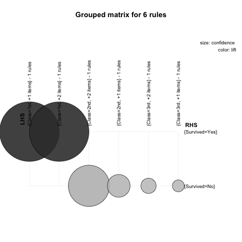

[output not shown]

```python
#=========================================
# IF USING R, RUN THIS CODE
#=========================================
# do not change the arules code
%R rules <- apriori(titanic.raw,parameter = list(minlen=2, supp=0.05, conf=0.8), appearance = list(rhs=c("Survived=No", "Survived=Yes"), default="lhs"), control = list(verbose=F))
%R rules.sorted <- sort(rules, by="lift")

# change or add plots using the following lines:
%R plot(rules.sorted, method="grouped", measure = 'confidence', shading='lift')

print('The Graphic for rules grouped by lift and their support')
```

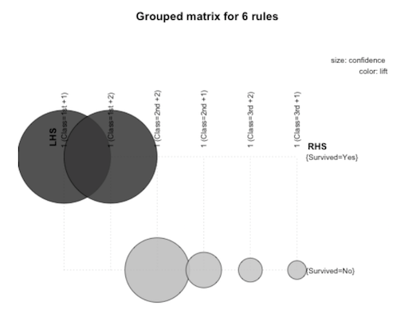

```python
#======================================================================
#IF NOT USING R RUN THIS BLOCK AND THE BLOCK AFTERWARD TO SEE EXAMPLES
#======================================================================
from IPython.display import Image
Image('Arules_grouped.png')
```

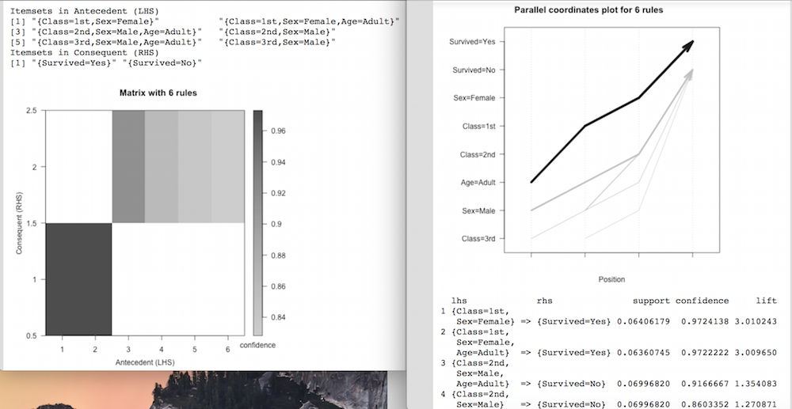

```python
Image('Arules_graph2_3.png')
```

Enter your answer here:

- The rule with highest confidence and highest lift is [1st Class, Female, Yes]
- It seems [1st Class, Female, Adult, Yes] can be another high lift and confidence. It seems there are no significant differences.

**Question**: Who is the lead author (and maintainer) for the arules package and the arulesViz package? What University does he/she currently teach at?

http://cran.r-project.org/web/packages/arules/arules.pdf

http://cran.r-project.org/web/packages/arulesViz/arulesViz.pdf

Enter your answer here:

Dr. M. Hahsler, SMU

That's all! Please **upload your rendered notebook** and please include **team member names** in the notebook submission.